# Corona Analysis

Samuel Knapp - samuel.k@gmx.de

# Download data

```r
# if you get a Import- or ModuleNotFound-Error in the python part below run these next 3 lines once on your machine:
# or on a terminal do: 'pip install python-dateutil, requests, bs4'

library(reticulate)
#use_python("/usr/local/bin/python")  # change to whatever your desired python path is
# use_virtualenv("~/myenv")
#py_install("bs4")
#py_install("requests")
#py_install("python-dateutil")

#reticulate::py_config() # check python version
```

## Population data

```python
wiki_pop_url = 'https://en.wikipedia.org/wiki/List_of_countries_and_dependencies_by_population'
```

Population data taken from wikipedia: https://en.wikipedia.org/wiki/List_of_countries_and_dependencies_by_population. Most numbers are from national or UN annual projections.

```python
#crawl wikipedia page for population data:
#print(sys.version)
from datetime import datetime, date
from dateutil import parser
from bs4 import BeautifulSoup
import requests

def clean_date(in_str):
    str_spl = in_str.split(' ')
    date_from_str = None
    if len(str_spl) == 3:
        date_from_str = parser.parse(in_str)  # datetime.strptime(in_str, '%d %b %Y')
    if len(str_spl) == 1:
        date_from_str = parser.parse(in_str)  # datetime.strptime(in_str, '%Y')
    return date_from_str.strftime("%Y-%m-%d")


def world_population_from_wiki_to_csv():
    r = 'country,population,last_updated_at_wiki\n'
    html = BeautifulSoup(
        requests.get('https://en.wikipedia.org/wiki/List_of_countries_and_dependencies_by_population').content,
        features='html.parser').prettify()
    s = BeautifulSoup(html, features='html.parser')
    rows = s.find('table').find('tbody').find_all('tr')
    data = []
    for row in rows:
        cols = row.find_all('td')
        cols = [ele.text.strip() for ele in cols]
        data.append([ele for ele in cols])
    for i in data:
        if i:
            r = r + str(i[1].split('\n')[0].replace(',', '')) + ',' + str(i[2].replace(',', '')) + ',' + clean_date(str(i[4])) + '\n'
    # replace United States with US:
    r = r.replace('United States', 'US')
    with open('pop_fresh.csv', 'w') as f:
        f.write(r)
    # return r

# now call the funcion to get newest population data from wikipedia into csv file:
world_population_from_wiki_to_csv()
```

Projection range of population data:

```r
pop_fresh <- fread("pop_fresh.csv")
# format date
pop_fresh[,last_updated_at_wiki:=as.Date(last_updated_at_wiki,tryFormats = c("%Y-%m-%d"))]

min(pop_fresh$last_updated_at_wiki)
```

```
## [1] "2015-10-15"
```

```r
max(pop_fresh$last_updated_at_wiki)
```

```
## [1] "2020-07-01"
```

## Covid-19 data

Data were downloaded from the github repository of the Johns Hopkins University. These are the same data, from which the famous GIS world map is created. See: https://github.com/CSSEGISandData/COVID-19.

```r
base_url = "https://raw.githubusercontent.com/CSSEGISandData/COVID-19/master"
cases_url = paste(
  base_url,
  "/csse_covid_19_data/csse_covid_19_time_series",
  "/time_series_covid19_confirmed_global.csv", sep="")
cases <- fread(cases_url)
# turn into long format
datecols <- names(cases)[-c(1:4)]
idcols <- names(cases)[c(1:4)]
cases <- melt(cases,id.vars=idcols,measure.vars=datecols,variable.name="date")
cases$action<-"confirmed"

#add death
death_data_url = paste(
  base_url,
  "/csse_covid_19_data/csse_covid_19_time_series",
  "/time_series_covid19_deaths_global.csv", sep="")
death <- fread(death_data_url)
datecols <- names(death)[-c(1:4)]
idcols <- names(death)[c(1:4)]
death <- melt(death,id.vars=idcols,measure.vars=datecols,variable.name="date")
death$action<-"death"
# bind
cases <- rbind(cases,death)

#################################
# some renaming
setnames(cases,"Country/Region","country")
setnames(cases,"Province/State","province")
setnames(cases,"value","number")

# format date
cases[,date:=as.Date(date,tryFormats = c("%m/%d/%y"))]
# number of days after first date in table
cases[,days:=as.numeric(date-min(date))]



# as Hong Kong is listed as country China, take out Hong Kong and set as country
cases[province=="Hong Kong",country:="Hong Kong"]


# sum over provinces for China
chinadat <- cases[country=="China"]
chinadat <- chinadat[,.(number=sum(number)),.(date,days,action,country)]
cut <- cases[!country=="China"]
cases <- rbind(cut,chinadat,fill=T)

# remove cruise ships
cases <- cases[!(country%in%c("Diamond Princess","MS Zaandam"))]

# remove * in Taiwan*
cases[country=="Taiwan*",country:="Taiwan"]

# some countries have outside provinces, mainland is identified by empty province

counts <- c("France","United Kingdom","Denmark","Netherlands","Canada")
for (counti in counts)
{
  changecases <- cases[country==counti& province==""]
  cases <- cases[country!=counti]
  cases <- rbind(cases,changecases)
}


# add population from
# https://en.wikipedia.org/wiki/List_of_countries_and_dependencies_by_population
#pop <- fread("pop.csv")

# use this line if you generated your own pop_fresh.csv file from python chunk above
pop <- fread("pop_fresh.csv")

# unique(cases$country)[!(unique(cases$country) %in% pop$country)]
cases <- merge(cases,pop,by="country",all.x=T)

# check how many countries and population
# contsum <- cases[,.(pop=unique(population)),country]
# nrow(contsum)
# sum(contsum$pop,na.rm=T)
```

Newest date

```r
max(cases$date)
```

```
## [1] "2020-06-16"
```

# Selected countries

```r
# number of countries to be plotted
nplot <- 25

# countries that shall definetly be selected
countadd <- c("Germany","Switzerland","Hong Kong",
              "Singapore","Sweden","Austria","Greece")
# set actioni to confirmed or death
actioni <- "death"

# table with most cases for given action
countover <- cases[action==actioni,.(maxnumber=max(number)),country]
countmost <- countover[order(-maxnumber),country]
# remove chosen countries
countmost <- countmost[!(countmost %in% countadd)]
countsel <- c(countadd,countmost[1:(nplot-length(countadd))])
#countsel
countsel <- sort(countsel)
```

# Actual numbers

The number of confirmed and death cases for each day.

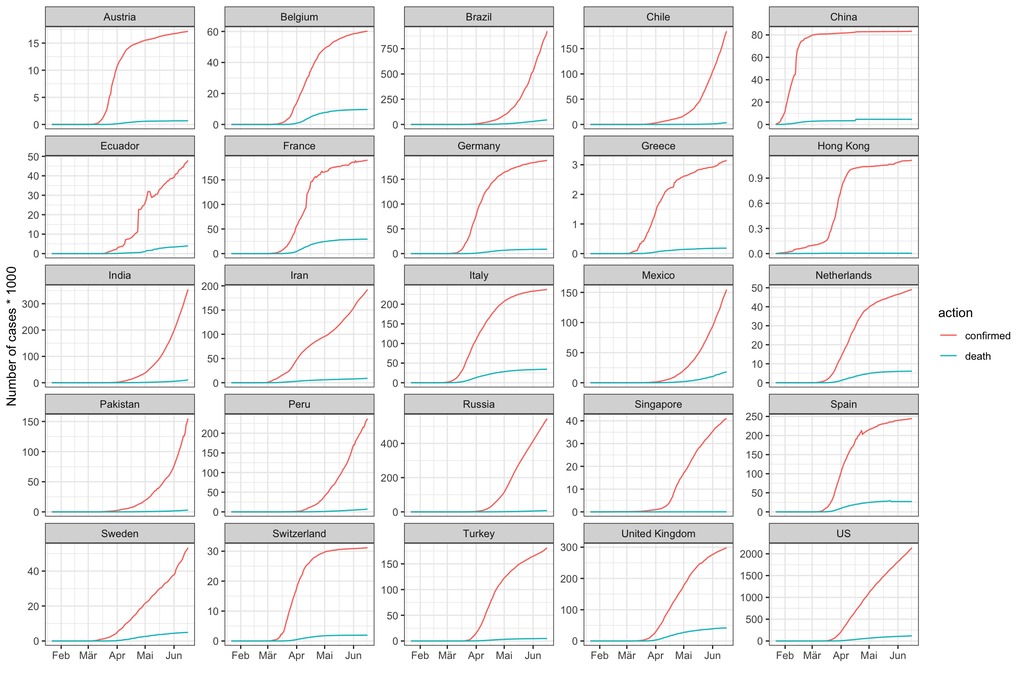

```r
# # cases per country, both confirmed and death
ggplot(cases[country%in%countsel],aes(date,number/1000,colour=action))+
  facet_wrap(vars(country),scales="free_y")+
  labs(x="",y="Number of cases * 1000")+
  geom_line()+
  theme_bw()
```

# Ratio of death to infected

Simply the ratio of reported deaths divided by number of confirmed cases for each day. Interesting to see that this ratio increases i most countries. A particularly sharp increase can be observed for countries that start to struggle: Italy, Spain, and Belgium. However, this calculation is probably too simple, as it does not take account of recovered cases.

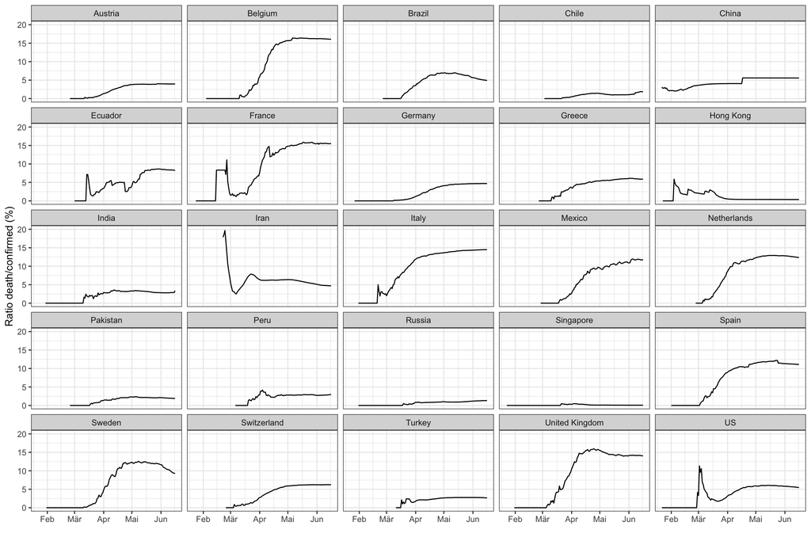

```r
#
# ################
# # use wide form
# wide form with columns for confirmed and death
# produces error for United Kingdom when 'Lat+Long' is included
casw <- dcast(cases,country+province+date~action,value.var="number")
#casw <- dcast(cases,country+date~action,value.var="number")

casw[,ratio:=death/confirmed]
ggplot(casw[country%in%countsel],aes(date,ratio*100))+
  facet_wrap(vars(country),#scales="free_y"
             )+
  geom_line()+
  labs(x="",y="Ratio death/confirmed (%)")+
  lims(y=c(0,20))+
  theme_bw()
```

```r
#
#
```

```r
#
# ################
# # use wide form
# wide form with columns for confirmed and death

# ggplot(casw['United Kingdom'],aes(date,ratio*100))+
#   facet_wrap(vars(country),#scales="free_y"
#              )+
#   geom_line()+
#   labs(x="",y="Ratio death/confirmed (%)")+
#   lims(y=c(0,20))+
#   theme_bw()
# #
# #
```

# New cases

Simply the daily increase of confirmed cases.

```r
cases[,newcases:=number-shift(number),country]
cases[,relnewcases:=number/shift(number),country]
# remove ones
cases <- cases[relnewcases!=1]
```

## Relative increase per day

A relative increase of e.g. b=1.2 indicates that the number of confirmed cases increases by 20% in one day, e.g. from 1000 to 1200. This number (b) can be related to the number of days needed for doubling the number of confirmed cases by $b^x=2$, with $x$ as the number of days. The following shows the relation of $b$ to $x$. The sometimes mentioned aim of a doubling time of ten days thus corresponds to $b\approx1.07$.

```r
b=seq(1.05,1.4,0.05)
tab <- data.frame(b=b,
                  NumberOfDays=log(2)/log(b))
kable(tab,digits=2)
```

| b | NumberOfDays |
| --- | --- |
| 1.05 | 14.21 |
| 1.10 | 7.27 |
| 1.15 | 4.96 |
| 1.20 | 3.80 |
| 1.25 | 3.11 |
| 1.30 | 2.64 |
| 1.35 | 2.31 |
| 1.40 | 2.06 |

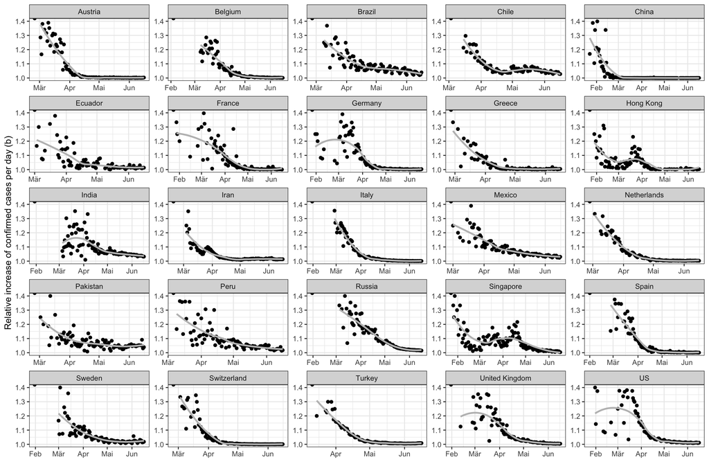

```r
ggplot(cases[country%in%countsel&action=="confirmed"],aes(date,relnewcases))+
  facet_wrap(vars(country),scales = "free")+
  geom_point()+
  geom_smooth(col="grey",se=F)+
  #geom_smooth(col="grey",se=F,method="lm",formula = y ~ x + I(x^2))+
  #scale_y_continuous(expand = expand_scale(mult = c(0.0001, .2))) +
  labs(x="",y="Relative increase of confirmed cases per day (b)")+
  lims(y=c(1,1.4))+
  theme_bw()
```

## Absolute increase

### Absolute numbers

For the capacity of the health systems, it is more important to look at the absolute numbers of new confirmed cases. The aim should be to get a constant number of new cases at a niveau which can be handled by the health system.

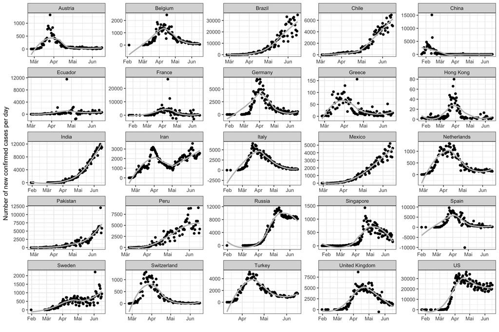

```r
ggplot(cases[country%in%countsel&action=="confirmed"],aes(date,newcases))+
  facet_wrap(vars(country),scales = "free")+
  #geom_hline(aes(yintercept=newvent))+
  geom_point()+
  geom_smooth(col="grey",se=F)+
  labs(x="",y="Number of new confirmed cases per day")  +
  #lims(y=c(1,1.5))+
  theme_bw()
```

### As number per 100 thousand inhabitants

Relating the absolute number of new cases to the total population per country. All in similar range, but still different. Not sure about the interpretation.

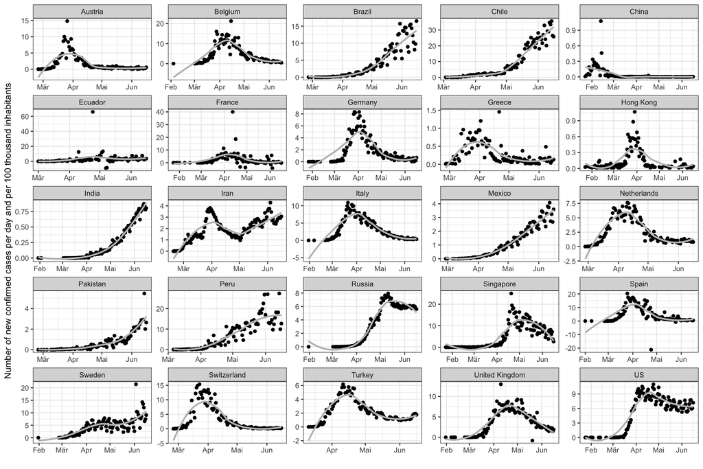

```r
cases[,newcases_pop:=newcases/population]
ggplot(cases[country%in%countsel&action=="confirmed"],aes(date,newcases_pop*100000))+
  facet_wrap(vars(country),scales = "free")+
  #geom_hline(aes(yintercept=newvent))+
  geom_point()+
  geom_smooth(col="grey",se=F)+
  #scale_y_continuous(expand = expand_scale(mult = c(0.0001, .2))) +
  labs(x="",y="Number of new confirmed cases per day and per 100 thousand inhabitants")  +
  #lims(y=c(1,1.5))+
  theme_bw()
```

# Percentage of population

Number of confirmed cases (most recent day) divided by the total population.

```r
ratab <- cases[action=="confirmed",.(RatioPercent=max(number)/max(population)*100),.(country)]
kable(head(ratab[order(-RatioPercent)],48),digits=3)
```

| country | RatioPercent |
| --- | --- |
| Qatar | 2.936 |
| San Marino | 2.068 |
| Bahrain | 1.267 |
| Andorra | 1.101 |
| Chile | 0.948 |
| Kuwait | 0.836 |
| Peru | 0.723 |
| Singapore | 0.718 |
| Luxembourg | 0.651 |
| US | 0.648 |
| Armenia | 0.591 |
| Belarus | 0.589 |
| Maldives | 0.559 |
| Oman | 0.544 |
| Belgium | 0.522 |
| Panama | 0.521 |
| Spain | 0.516 |
| Sweden | 0.516 |
| Ireland | 0.515 |
| Iceland | 0.495 |
| Moldova | 0.457 |
| United Kingdom | 0.446 |
| Brazil | 0.436 |
| United Arab Emirates | 0.435 |
| Djibouti | 0.421 |
| Saudi Arabia | 0.398 |
| Italy | 0.394 |
| Russia | 0.371 |
| Portugal | 0.363 |
| Switzerland | 0.362 |
| France | 0.283 |
| Netherlands | 0.281 |
| Ecuador | 0.274 |
| Monaco | 0.260 |
| Iran | 0.230 |
| Dominican Republic | 0.229 |
| Germany | 0.226 |
| Turkey | 0.218 |
| Israel | 0.212 |
| Liechtenstein | 0.212 |
| Denmark | 0.210 |
| North Macedonia | 0.207 |
| Austria | 0.193 |
| Gabon | 0.189 |
| Serbia | 0.178 |
| Bolivia | 0.173 |
| Norway | 0.161 |
| Estonia | 0.149 |